# MovieLens Project

Myint Moe Chit

13/06/2019

# Introduction

One of the applications of machine learning is predicting the response of a consumer as accurate as possible. In this project, I attempt to develop a model that predict the rating given by user on a movie using the methodology described in Irizarry (2019). To develop the basic machine learning model, I use a subset of the database generated by GroupLens research lab. The dataset includes 10 million ratings for 10677 movies by 69878 users.

The goal of the project is to develop a machine learning algorithm that can predict movie rating relatively accurately. The accuracy of the algorithm is measured by the residual mean squared error (RMSE) on a test (validation) dataset. The target accuracy of the project is to achieve an RMSE score lower than 0.8775. Since RMSE can be interpret as a typical predicting error, the target is to achieve the margin of error lower than 0.87 star.

To achieve the targeted value of RMSE, I train a machine learning algorithm using the inputs in a subset of the data (a train set with about 9 million observations) to predict movie ratings in the validation set (about 1 million observations).

# Data preparation and method of analysis

The dataset used in this project is download from http://files.grouplens.org/datasets/movielens/ml-10m.zip and generate a data frame called “movielens” in R. The summary of data in tidy format is presented below.

```
## # A tibble: 10,000,054 x 6
##    userId movieId rating timestamp title            genres
##     <int>   <dbl>  <dbl>     <int> <chr>            <chr>
##  1      1     122      5 838985046 Boomerang (1992) Comedy|Romance
##  2      1     185      5 838983525 Net, The (1995)  Action|Crime|Thriller
##  3      1     231      5 838983392 Dumb & Dumber (… Comedy
##  4      1     292      5 838983421 Outbreak (1995)  Action|Drama|Sci-Fi|T…
##  5      1     316      5 838983392 Stargate (1994)  Action|Adventure|Sci-…
##  6      1     329      5 838983392 Star Trek: Gene… Action|Adventure|Dram…
##  7      1     355      5 838984474 Flintstones, Th… Children|Comedy|Fanta…
##  8      1     356      5 838983653 Forrest Gump (1… Comedy|Drama|Romance|…
##  9      1     362      5 838984885 Jungle Book, Th… Adventure|Children|Ro…
## 10      1     364      5 838983707 Lion King, The … Adventure|Animation|C…
## # ... with 10,000,044 more rows
```

To identify the factors that influence a user’s rating on a movie, first we analyse the distribution of the data.

The following distribution indicates that the different movies the number of ratings is different across the movies, indicating rating is associated with the movie.

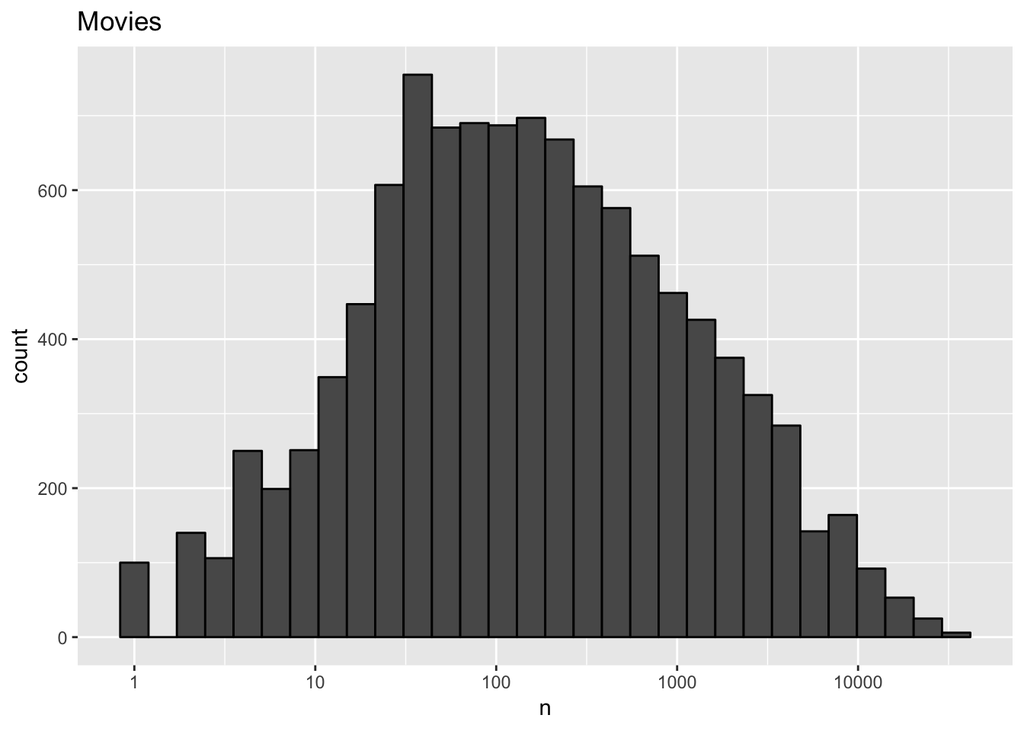

Then, we plot the distribution of rating across unique users. The following distribution suggests the number of rating given are also different across unique users.

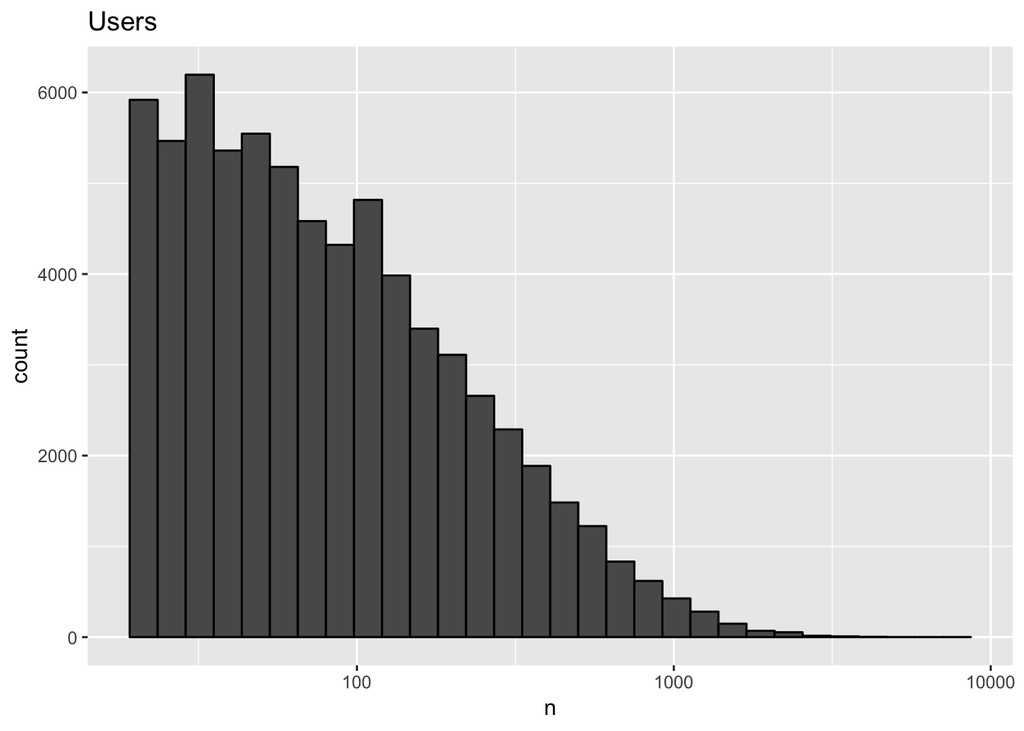

The data set also includes a variable that indicates the genre of the movie and some movies fall under several genres. To evaluate the association between the genre and a rating given on a movie, we first separate the genres and assign a movie to each genre. Then, we plot the average rating given to movies fall under different genre. Again, the following plot show the average rating differs across different genres suggesting rating is also influenced by the genre of a movie.

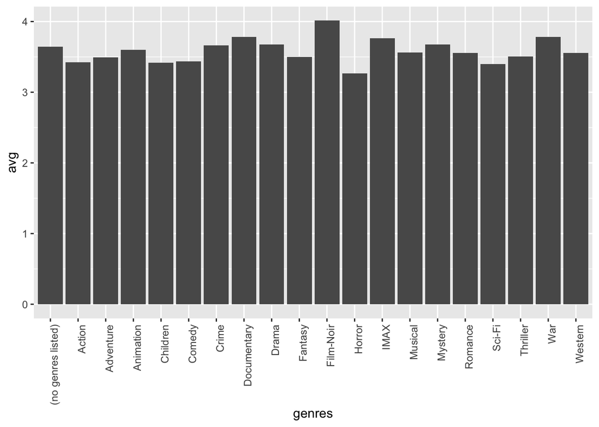

The plots presented above clearly show strong evidence of user, movie, genre effect.

To predict movie rating, I divide the data into training set and validation (test) set. The training set (90 percent of the observations) is used to build the algorithm which is then applied on the validation set (10% of the observations) to access the accuracy.

The accuracy of the model developed to predict movie rating will be measured by the residual mean squared error (RMSE) on the validation set.

The function that computes the RMSE for vectors of ratings and their corresponding predictors:

```r
RMSE <- function(true_ratings, predicted_ratings){
    sqrt(mean((true_ratings - predicted_ratings)^2))
}
```

The RMSE obtained from prediction can be interpreted as the typical error made in predicting a movie rating. If this number is larger than 1, the typical error made in prediction is larger than one star. The aim of this project is to build an algorithm that yields an RMSE lower than 0.8775.

# Analysis and Results

Following the simplified version of Normalisation of Global Effect method used in Irizarry (2019), I decompose the rating given by a user on a movie into four different components: the baseline rating (the average of all user-movie ratings), user-specific effect, movie-specific effect, and genre-specific effect.

First, I calculate the average rating of the users in the sample. The average rating is 3.54 star.

If we assume that the expected rating on a movie is 3.54 and the differences (lower of higher than the expected rating) were due to random variation. The accuracy of this prediction can be measured by RMSE. As shown in the following table RMSE of the model that use the average value to predict the movie rating is 1.06, suggesting the margin of estimation error is about 1 star.

## Modelling movie-specific bias

As demonstrated in the previous section, different movies get different rating and some movies get rated more than others. To develop a model for more accurate estimation, I calculate the movie-specific bias as outlined in Irizarry (2019). The movie-specific bias is calculated as the average of the differences between individual user’s rating on a specific movie and the expected (average) rating of all users-movies. The estimated movie-specific bias is calculate using the training data set.

As shown in the following plot, movie-specific bias vary significantly with a minimum of – 3 stars to a maximum of 1.5 stars.

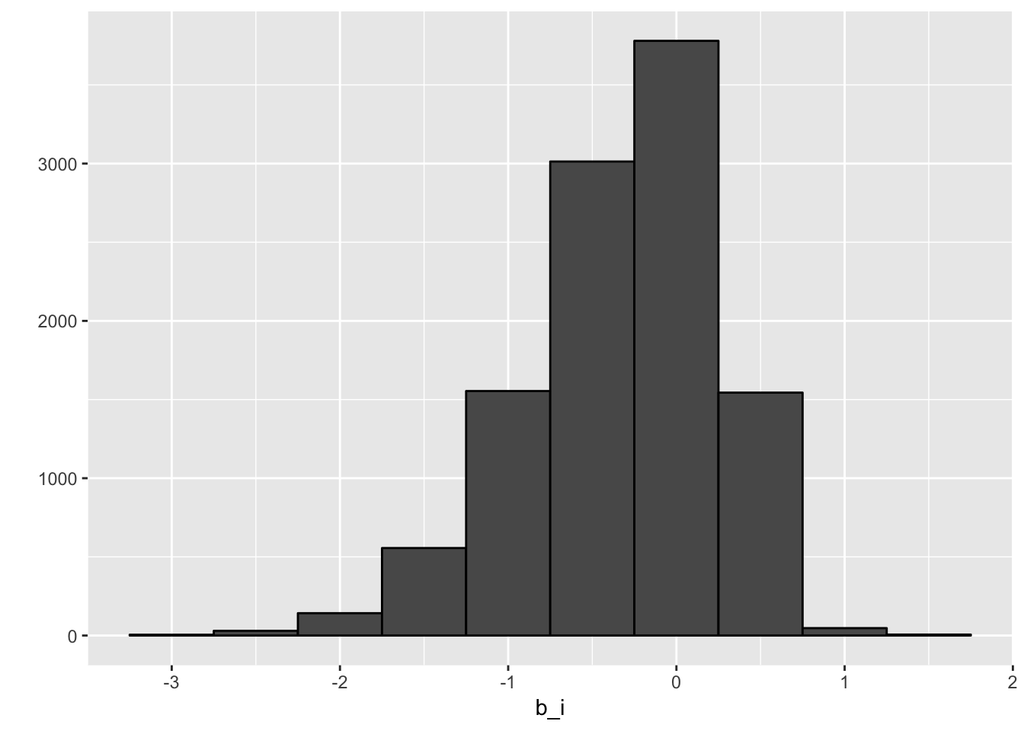

| method | RMSE |
| --- | --- |
| Just using the average | 1.0612018 |
| Movie-specific Effect Model | 0.9439087 |

## Model with Movie and User-specific bias

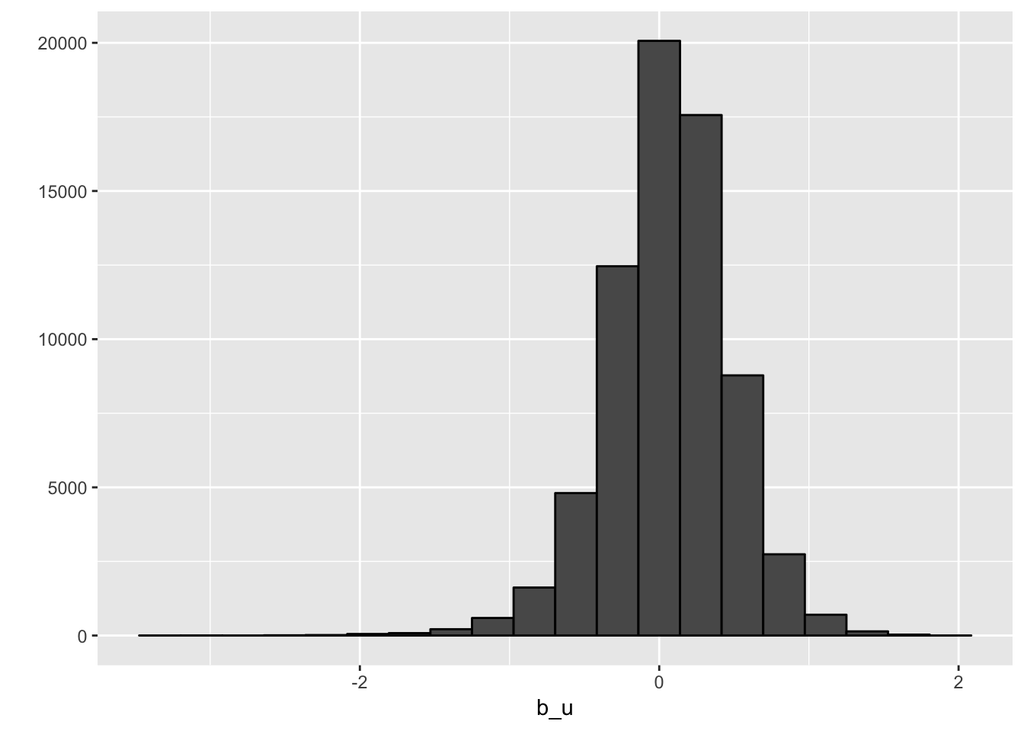

Then, I construct a prediction model that take account of the movie-specific and user-specific bias using the validation data. As shown in the table, RMSE of this approach has been improved and lower than that of the model with only movie-specific bias.

| method | RMSE |
| --- | --- |
| Just using the average | 1.0612018 |
| Movie-specific Effect Model | 0.9439087 |
| Movie + User-specific Effects Model | 0.8653488 |

## Model with Movie, User, and Genre-specific bias

Since the genre of a movie also influenced the movie rating, I develop a model with all three biases. The genre-specific bias is calculated as the average of the differences between individual user’s rating on a specific movie and the sum of expected (average) rating of all users-movies plus movie and user-specific biases. The estimated genre-specific bias is calculate using the training data set.

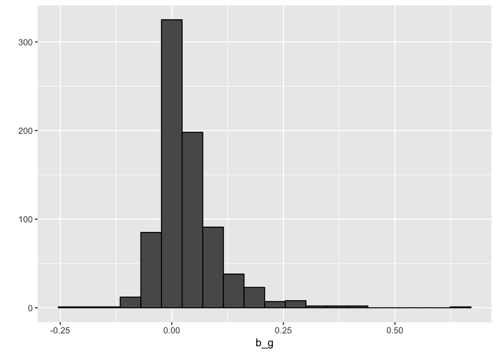

| method | RMSE |
| --- | --- |
| Just using the average | 1.0612018 |
| Movie-specific Effect Model | 0.9439087 |
| Movie + User-specific Effects Model | 0.8653488 |
| Movie + User + genres-specific Effects Model | 0.8649469 |

## Regularization

As suggested in Irizarry (2019). there could be potential uncertainty in our prediction due to the influence of the highest and the lowest ratings given to movies watched by very few users. To control for those noisy estimates that could affect our prediction, I apply regularisation method that penalise large estimates that are formed using small sample sizes. The penalty parameter, Lambda, is selected using a cross-validation method.

As shown in the above plot the value of Lambda that minimise RMSE is 5.

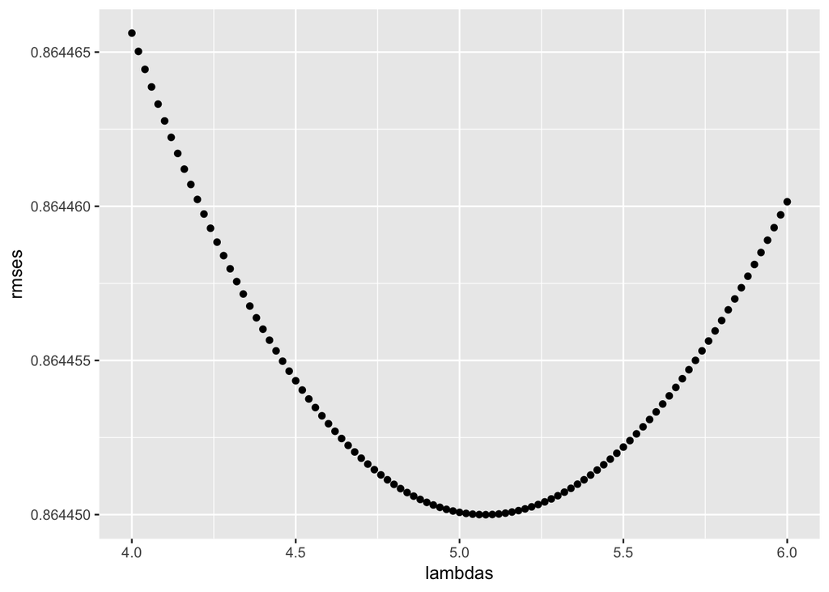

| method | RMSE |
| --- | --- |
| Just using the average | 1.0612018 |
| Movie-specific Effect Model | 0.9439087 |
| Movie + User-specific Effects Model | 0.8653488 |
| Movie + User + genres-specific Effects Model | 0.8649469 |
| Regularized Movie + User + Genres Effect Model | 0.8644500 |

# Conclusion